# Regresión en R, paso a paso

Ciencia de Datos para Economía y Negocios - FCE-UBA

Nicolás Sidicaro

# 1 Antes de empezar

## 1.1 Qué hay en esta guía

Esta guía es un recetario aplicado. La teoría aparece solo cuando hace falta para **decidir qué hacer** o **leer bien una salida**. El recorrido es siempre el mismo:

1. **Estimar** el modelo con `lm()`.
2. **Interpretar** los coeficientes (qué significa cada número).
3. **Testear** significatividad y supuestos.
4. **Corregir** lo que haga falta y volver a interpretar.

**Cómo usarla.** Copiar los bloques de código en un script propio y correrlos línea por línea (Ctrl+Enter). Cada sección cierra con una tabla de “qué hacer con tu base” para adaptar el código a los datos del trabajo final.

## 1.2 Paquetes

```r
# install.packages(c("wooldridge", "dplyr", "lmtest", "sandwich", "car",
#                    "AER", "plm", "tseries", "margins", "modelsummary"))

library(wooldridge)   # bases de datos del libro de Wooldridge
library(dplyr)        # manipulación de datos
library(lmtest)       # coeftest(), bptest(), dwtest(), bgtest(), resettest()
library(sandwich)     # vcovHC() (White), NeweyWest()
library(car)          # linearHypothesis(), vif()
library(AER)          # ivreg() para variables instrumentales
library(plm)          # datos de panel: efectos fijos y aleatorios
library(tseries)      # jarque.bera.test()
library(margins)      # efectos marginales en logit / probit
library(modelsummary) # tablas de resultados lado a lado
```

## 1.3 Los datos

Vamos a usar bases reales que vienen en el paquete `wooldridge`, así todos obtienen exactamente los mismos números.

| Base | Qué tiene | Para qué la usamos |
| --- | --- | --- |
| `wage1` | 526 trabajadores de EE.UU. (1976): salario, educación, experiencia, sexo, región | Regresión simple, múltiple, dummies, logs, supuestos |
| `phillips` | Serie anual de inflación y desempleo de EE.UU. | Autocorrelación |
| `mroz` | 753 mujeres casadas: participación laboral, salario, educación propia y de los padres | Variables instrumentales y variable dependiente binaria |
| `wagepan` | 545 varones seguidos entre 1980 y 1987 | Datos de panel |

```r
data("wage1")
glimpse(wage1[, c("wage", "lwage", "educ", "exper", "tenure", "female", "married")])
```

```
#> Rows: 526
#> Columns: 7
#> $ wage    <dbl> 3.10, 3.24, 3.00, 6.00, 5.30, 8.75, 11.25, 5.00, 3.60, 18.18, …
#> $ lwage   <dbl> 1.1314, 1.1756, 1.0986, 1.7918, 1.6677, 2.1691, 2.4204, 1.6094…
#> $ educ    <int> 11, 12, 11, 8, 12, 16, 18, 12, 12, 17, 16, 13, 12, 12, 12, 16,…
#> $ exper   <int> 2, 22, 2, 44, 7, 9, 15, 5, 26, 22, 8, 3, 15, 18, 31, 14, 10, 1…
#> $ tenure  <int> 0, 2, 0, 28, 2, 8, 7, 3, 4, 21, 2, 0, 0, 3, 15, 0, 0, 10, 0, 6…
#> $ female  <int> 1, 1, 0, 0, 0, 0, 0, 1, 1, 0, 1, 1, 0, 0, 0, 0, 1, 1, 1, 1, 1,…
#> $ married <int> 0, 1, 0, 1, 1, 1, 0, 0, 0, 1, 0, 0, 1, 0, 1, 1, 1, 0, 1, 1, 0,…
```

**Antes de estimar, siempre mirar los datos.** Un `summary()`, un histograma de la variable dependiente y un diagrama de dispersión contra la regresora principal ahorran muchos problemas (valores imposibles, códigos como 99 = “no sabe”, asimetrías fuertes que piden logaritmo).

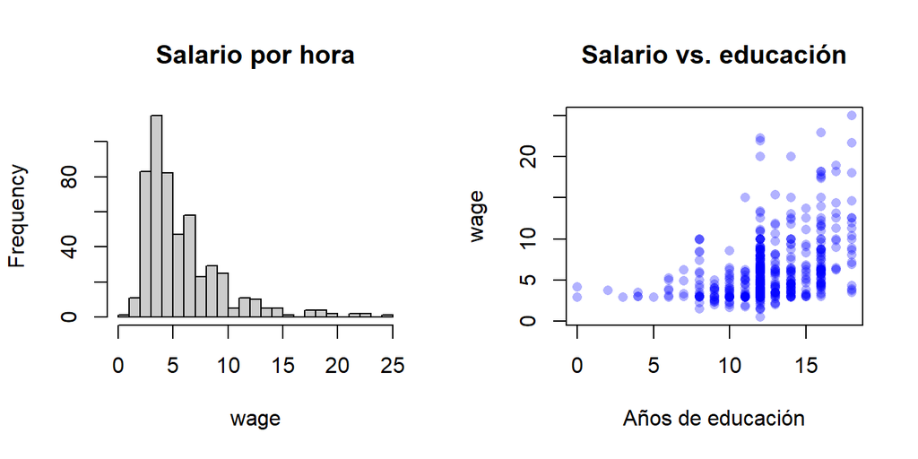

```r
par(mfrow = c(1, 2))
hist(wage1$wage, breaks = 30, main = "Salario por hora", xlab = "wage", col = "grey80")
plot(wage1$educ, wage1$wage, pch = 16, col = rgb(0, 0, 1, 0.3),
     main = "Salario vs. educación", xlab = "Años de educación", ylab = "wage")
```

```r
par(mfrow = c(1, 1))
```

# 2 Regresión lineal simple

## 2.1 Estimar

El modelo es $y = \beta_0 + \beta_1 x + u$. En R, la fórmula se escribe `y ~ x` (el intercepto se incluye solo).

```r
m_simple <- lm(wage ~ educ, data = wage1)
summary(m_simple)
```

```
#>
#> Call:
#> lm(formula = wage ~ educ, data = wage1)
#>
#> Residuals:
#>    Min     1Q Median     3Q    Max
#> -5.340 -2.150 -0.967  1.192 16.609
#>
#> Coefficients:
#>             Estimate Std. Error t value            Pr(>|t|)
#> (Intercept)  -0.9049     0.6850   -1.32                0.19
#> educ          0.5414     0.0532   10.17 <0.0000000000000002 ***
#> ---
#> Signif. codes:  0 '***' 0.001 '**' 0.01 '*' 0.05 '.' 0.1 ' ' 1
#>
#> Residual standard error: 3.38 on 524 degrees of freedom
#> Multiple R-squared:  0.165,  Adjusted R-squared:  0.163
#> F-statistic:  103 on 1 and 524 DF,  p-value: <0.0000000000000002
```

## 2.2 Cómo se lee la salida de `summary()`

| Parte de la salida | Qué es | Qué mirar |
| --- | --- | --- |
| `Estimate` | El coeficiente $\hat\beta$ | Signo y magnitud: es lo que se interpreta |
| `Std. Error` | Error estándar de $\hat\beta$ | Cuán precisa es la estimación |
| `t value` | $\hat\beta / \text{EE}$ | Estadístico del test $H_0: \beta = 0$ |
| `Pr(>\|t\|)` | p-valor de ese test | Si es < 0,05, el coeficiente es significativo al 5% |
| Estrellitas | Resumen visual del p-valor | `***` < 0,001; `**` < 0,01; `*` < 0,05; `.` < 0,1 |
| `Residual standard error` | Desvío estimado del error, $\hat\sigma$ | En unidades de $y$: el “error típico” de predicción |
| `Multiple R-squared` | $R^2$ | Proporción de la varianza de $y$ explicada por el modelo |
| `Adjusted R-squared` | $R^2$ ajustado | Penaliza agregar variables; sirve para comparar modelos con distinta cantidad de regresoras |
| `F-statistic` | Test de significatividad **global** | $H_0$: todos los $\beta$ (menos el intercepto) son cero |

## 2.3 Interpretar

- **Pendiente** ($\hat\beta_1$ = 0.541): cada año adicional de educación está asociado, en promedio, a un salario por hora 0.54 dólares mayor.
- **Intercepto** ($\hat\beta_0$ = -0.905): salario predicho con 0 años de educación. Acá no tiene sentido económico (casi nadie tiene 0 años y el valor es negativo): el intercepto muchas veces es solo un “ancla” de la recta.
- **$R^2$** = 0.165: la educación sola explica cerca del 16% de la variabilidad del salario.

**Asociación no es causalidad.** Que el coeficiente sea significativo no quiere decir que un año más de educación *cause* ese aumento. Si hay variables omitidas correlacionadas con la educación (habilidad, contactos familiares), el coeficiente está sesgado. Eso se ataca con regresión múltiple (sección 3) y, cuando no alcanza, con variables instrumentales (sección 8).

## 2.4 Graficar la recta y extraer resultados

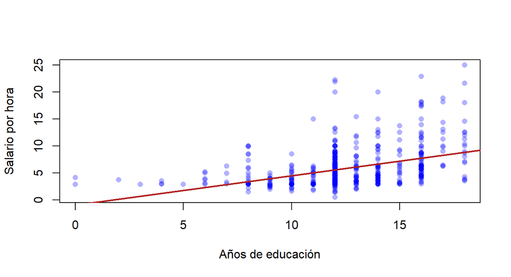

```r
plot(wage1$educ, wage1$wage, pch = 16, col = rgb(0, 0, 1, 0.3),
     xlab = "Años de educación", ylab = "Salario por hora")
abline(m_simple, col = "firebrick", lwd = 2)
```

Funciones útiles para sacar cosas del modelo:

```r
coef(m_simple)            # coeficientes
confint(m_simple)         # intervalos de confianza al 95%
fitted(m_simple)          # valores predichos (y sombrero)
residuals(m_simple)       # residuos (y - y sombrero)
nobs(m_simple)            # cantidad de observaciones usadas
summary(m_simple)$r.squared
```

## 2.5 Predecir

`predict()` recibe un data frame con valores nuevos de las regresoras.

```r
nuevos <- data.frame(educ = c(12, 16))
predict(m_simple, newdata = nuevos, interval = "confidence")  # salario PROMEDIO
```

```
#>     fit   lwr   upr
#> 1 5.591 5.296 5.887
#> 2 7.757 7.295 8.218
```

```r
predict(m_simple, newdata = nuevos, interval = "prediction")  # salario de UNA persona
```

```
#>     fit    lwr   upr
#> 1 5.591 -1.052 12.23
#> 2 7.757  1.104 14.41
```

El intervalo de predicción es mucho más ancho: predecir el promedio de un grupo es más fácil que predecir a un individuo concreto.

# 3 Regresión lineal múltiple

## 3.1 Estimar

Se agregan regresoras con `+`:

```r
m_mult <- lm(wage ~ educ + exper + tenure, data = wage1)
summary(m_mult)
```

```
#>
#> Call:
#> lm(formula = wage ~ educ + exper + tenure, data = wage1)
#>
#> Residuals:
#>    Min     1Q Median     3Q    Max
#> -7.607 -1.775 -0.628  1.197 14.654
#>
#> Coefficients:
#>             Estimate Std. Error t value             Pr(>|t|)
#> (Intercept)  -2.8727     0.7290   -3.94    0.000092247424963 ***
#> educ          0.5990     0.0513   11.68 < 0.0000000000000002 ***
#> exper         0.0223     0.0121    1.85                0.064 .
#> tenure        0.1693     0.0216    7.82    0.000000000000029 ***
#> ---
#> Signif. codes:  0 '***' 0.001 '**' 0.01 '*' 0.05 '.' 0.1 ' ' 1
#>
#> Residual standard error: 3.08 on 522 degrees of freedom
#> Multiple R-squared:  0.306,  Adjusted R-squared:  0.302
#> F-statistic: 76.9 on 3 and 522 DF,  p-value: <0.0000000000000002
```

## 3.2 Interpretar: *ceteris paribus*

Cada coeficiente es el efecto de su variable **manteniendo constantes las demás incluidas en el modelo**.

- `educ`: un año más de educación se asocia a 0.6 dólares más por hora, **para dos personas con la misma experiencia y la misma antigüedad** en la empresa.
- `tenure`: un año más de antigüedad en el empleo actual se asocia a 0.17 dólares más por hora, dejando fijas educación y experiencia.

**¿Por qué cambió el coeficiente de educación?** En la regresión simple era 0.541 y ahora es 0.599. El coeficiente simple “absorbía” parte del efecto de variables correlacionadas con la educación que no estaban en el modelo. Ese es el **sesgo por variable omitida**: cuando cambia mucho un coeficiente al agregar controles, es señal de que importaban.

## 3.3 Comparar modelos

Con distinta cantidad de variables, comparar con **$R^2$ ajustado** (o AIC/BIC, cuanto menor mejor), nunca con $R^2$ a secas porque siempre sube al agregar variables.

```r
data.frame(
  modelo   = c("simple", "múltiple"),
  R2       = c(summary(m_simple)$r.squared, summary(m_mult)$r.squared),
  R2_ajust = c(summary(m_simple)$adj.r.squared, summary(m_mult)$adj.r.squared),
  AIC      = c(AIC(m_simple), AIC(m_mult))
)
```

| modelo | R2 | R2_ajust | AIC |
| --- | --- | --- | --- |
| simple | 0.1648 | 0.1632 | 2777 |
| múltiple | 0.3064 | 0.3024 | 2684 |

Los $R^2$ solo se pueden comparar entre modelos con **la misma variable dependiente**. Un modelo con `wage` y otro con `log(wage)` no son comparables por $R^2$.

# 4 Variables dummy y categóricas

## 4.1 Una dummy (0/1)

`female` vale 1 si es mujer y 0 si es varón. Su coeficiente es la **diferencia de intercepto** entre grupos: rectas paralelas.

```r
m_dummy <- lm(wage ~ female + educ + exper + tenure, data = wage1)
coeftest(m_dummy)
```

```
#>
#> t test of coefficients:
#>
#>             Estimate Std. Error t value             Pr(>|t|)
#> (Intercept)  -1.5679     0.7246   -2.16                0.031 *
#> female       -1.8109     0.2648   -6.84       0.000000000023 ***
#> educ          0.5715     0.0493   11.58 < 0.0000000000000002 ***
#> exper         0.0254     0.0116    2.20                0.029 *
#> tenure        0.1410     0.0212    6.66       0.000000000068 ***
#> ---
#> Signif. codes:  0 '***' 0.001 '**' 0.01 '*' 0.05 '.' 0.1 ' ' 1
```

**Interpretación**: a igual educación, experiencia y antigüedad, las mujeres ganan en promedio 1.81 dólares por hora **menos** que los varones (el grupo base, el que vale 0).

## 4.2 Categóricas con más de dos niveles

Con una variable de $k$ categorías se incluyen $k-1$ dummies: la que se omite es la **categoría base** y todos los coeficientes se leen **en comparación con ella**. Si se incluyen las $k$ junto con el intercepto, R no puede estimar (trampa de la variable dummy: multicolinealidad perfecta).

La forma práctica en R es crear un `factor`: `lm()` arma las dummies solo.

```r
wage1 <- wage1 %>%
  mutate(region = case_when(
    northcen == 1 ~ "Centro-norte",
    south    == 1 ~ "Sur",
    west     == 1 ~ "Oeste",
    TRUE          ~ "Noreste"
  ),
  region = factor(region))

levels(wage1$region)   # la primera (orden alfabético) es la base
```

```
#> [1] "Centro-norte" "Noreste"      "Oeste"        "Sur"
```

```r
m_region <- lm(wage ~ educ + exper + tenure + region, data = wage1)
coeftest(m_region)
```

```
#>
#> t test of coefficients:
#>
#>               Estimate Std. Error t value             Pr(>|t|)
#> (Intercept)    -3.2544     0.7784   -4.18    0.000034052600637 ***
#> educ            0.5963     0.0513   11.63 < 0.0000000000000002 ***
#> exper           0.0238     0.0120    1.98               0.0480 *
#> tenure          0.1681     0.0216    7.79    0.000000000000036 ***
#> regionNoreste   0.6567     0.3892    1.69               0.0921 .
#> regionOeste     1.1232     0.4209    2.67               0.0079 **
#> regionSur       0.1649     0.3506    0.47               0.6383
#> ---
#> Signif. codes:  0 '***' 0.001 '**' 0.01 '*' 0.05 '.' 0.1 ' ' 1
```

Acá la base es “Centro-norte”. Por ejemplo, `regionSur` indica cuánto más (o menos) gana alguien del Sur respecto de alguien del Centro-norte con iguales educación, experiencia y antigüedad.

Para **cambiar la categoría base** se usa `relevel()`:

```r
wage1$region <- relevel(wage1$region, ref = "Noreste")
m_region <- lm(wage ~ educ + exper + tenure + region, data = wage1)
coeftest(m_region)
```

```
#>
#> t test of coefficients:
#>
#>                    Estimate Std. Error t value             Pr(>|t|)
#> (Intercept)         -2.5977     0.7746   -3.35              0.00086 ***
#> educ                 0.5963     0.0513   11.63 < 0.0000000000000002 ***
#> exper                0.0238     0.0120    1.98              0.04803 *
#> tenure               0.1681     0.0216    7.79    0.000000000000036 ***
#> regionCentro-norte  -0.6567     0.3892   -1.69              0.09210 .
#> regionOeste          0.4665     0.4312    1.08              0.27981
#> regionSur           -0.4918     0.3633   -1.35              0.17637
#> ---
#> Signif. codes:  0 '***' 0.001 '**' 0.01 '*' 0.05 '.' 0.1 ' ' 1
```

**Nunca meter una categórica codificada como número** (1 = Norte, 2 = Sur, 3 = …). R la trata como continua y estima un único efecto por “subir un código”, que no tiene sentido. Si la variable viene numérica, convertirla con `factor()`.

Para saber si la región **en conjunto** importa, no alcanza con mirar cada dummy: se testean todas juntas (ver sección 6.3).

## 4.3 Interacciones: distinta pendiente según el grupo

Si creemos que el retorno a la educación **difiere** entre varones y mujeres, se interactúa la dummy con la variable continua. `female * educ` incluye `female`, `educ` y el producto `female:educ`.

```r
m_inter <- lm(wage ~ female * educ + exper + tenure, data = wage1)
coeftest(m_inter)
```

```
#>
#> t test of coefficients:
#>
#>             Estimate Std. Error t value             Pr(>|t|)
#> (Intercept)  -2.2746     0.8723   -2.61               0.0094 **
#> female       -0.0600     1.2348   -0.05               0.9613
#> educ          0.6258     0.0619   10.12 < 0.0000000000000002 ***
#> exper         0.0256     0.0116    2.22               0.0270 *
#> tenure        0.1423     0.0212    6.73       0.000000000046 ***
#> female:educ  -0.1397     0.0963   -1.45               0.1472
#> ---
#> Signif. codes:  0 '***' 0.001 '**' 0.01 '*' 0.05 '.' 0.1 ' ' 1
```

- `educ`: retorno de la educación para **varones** (grupo base).
- `female:educ`: cuánto **cambia** ese retorno para las mujeres. Retorno para mujeres = `educ` + `female:educ`.
- `female`: diferencia de intercepto (con `educ` = 0; en general poco interpretable sola cuando hay interacción).

**Test de Chow en versión práctica.** Para preguntar si *toda* la ecuación difiere entre grupos, se interactúa la dummy con todas las regresoras y se testea que todos los términos con `female` sean cero a la vez:

```r
m_restr   <- lm(wage ~ educ + exper + tenure, data = wage1)
m_completo <- lm(wage ~ female * (educ + exper + tenure), data = wage1)
anova(m_restr, m_completo)   # p < 0,05: las ecuaciones difieren entre grupos
```

| Res.Df | RSS | Df | Sum of Sq | F | Pr(>F) |
| --- | --- | --- | --- | --- | --- |
| 522 | 4966 | NA | NA | NA | NA |
| 518 | 4394 | 4 | 572.1 | 16.86 | 0 |

# 5 Logaritmos y términos cuadráticos

## 5.1 Logaritmos

El modelo sigue siendo **lineal en los parámetros**: solo se transforma la variable. Conviene usar logaritmos cuando la variable es positiva y asimétrica (salarios, ingresos, precios, ventas, población) o cuando interesa hablar en **porcentajes**.

```r
m_loglin <- lm(log(wage) ~ educ + exper + tenure, data = wage1)
coeftest(m_loglin)
```

```
#>
#> t test of coefficients:
#>
#>             Estimate Std. Error t value             Pr(>|t|)
#> (Intercept)  0.28436    0.10419    2.73               0.0066 **
#> educ         0.09203    0.00733   12.56 < 0.0000000000000002 ***
#> exper        0.00412    0.00172    2.39               0.0171 *
#> tenure       0.02207    0.00309    7.13      0.0000000000033 ***
#> ---
#> Signif. codes:  0 '***' 0.001 '**' 0.01 '*' 0.05 '.' 0.1 ' ' 1
```

**Tabla de interpretación** (para cambios chicos en $x$):

| Modelo | Fórmula en R | Interpretación de $\beta_1$ |
| --- | --- | --- |
| lin-lin | `y ~ x` | $\Delta x = 1 \Rightarrow \Delta y = \beta_1$ unidades |
| log-lin | `log(y) ~ x` | $\Delta x = 1 \Rightarrow y$ cambia $100\cdot\beta_1$ % |
| lin-log | `y ~ log(x)` | $x$ sube 1% $\Rightarrow y$ cambia $\beta_1/100$ unidades |
| log-log | `log(y) ~ log(x)` | $x$ sube 1% $\Rightarrow y$ cambia $\beta_1$ % (**elasticidad**) |

En el modelo estimado: un año más de educación se asocia a un salario **9.2% mayor**, manteniendo constantes experiencia y antigüedad.

Ejemplo log-log con precios de viviendas (`hprice1`):

```r
data("hprice1")
m_loglog <- lm(log(price) ~ log(lotsize) + log(sqrft) + bdrms, data = hprice1)
coeftest(m_loglog)
```

```
#>
#> t test of coefficients:
#>
#>              Estimate Std. Error t value      Pr(>|t|)
#> (Intercept)   -1.2970     0.6513   -1.99          0.05 *
#> log(lotsize)   0.1680     0.0383    4.39 0.00003306740 ***
#> log(sqrft)     0.7002     0.0929    7.54 0.00000000005 ***
#> bdrms          0.0370     0.0275    1.34          0.18
#> ---
#> Signif. codes:  0 '***' 0.001 '**' 0.01 '*' 0.05 '.' 0.1 ' ' 1
```

Si la superficie construida (`sqrft`) aumenta 1%, el precio aumenta en promedio 0.7%, a igual terreno y cantidad de dormitorios.

**Dummies con `log(y)`**: el coeficiente $\times 100$ es solo una aproximación, que empeora cuando el coeficiente es grande (más de 0,1 en valor absoluto). La diferencia porcentual exacta es $100 \cdot (e^{\hat\beta} - 1)$:

```r
m_logfem <- lm(log(wage) ~ female + educ + exper + tenure, data = wage1)
b_fem <- coef(m_logfem)["female"]
c(aproximado = 100 * b_fem, exacto = 100 * (exp(b_fem) - 1))
```

```
#> aproximado.female     exacto.female
#>            -30.11            -26.00
```

**`log(0)` no existe.** Si la variable tiene ceros, `log()` devuelve `-Inf` y `lm()` falla o descarta filas. Revisar antes (`sum(x <= 0)`).

## 5.2 Términos cuadráticos

Sirven cuando el efecto de $x$ **cambia** a medida que $x$ crece (rendimientos decrecientes o crecientes). En la fórmula hay que usar `I()`, porque dentro de una fórmula `^` tiene otro significado:

```r
m_cuad <- lm(log(wage) ~ educ + exper + I(exper^2) + tenure, data = wage1)
coeftest(m_cuad)
```

```
#>
#> t test of coefficients:
#>
#>              Estimate Std. Error t value             Pr(>|t|)
#> (Intercept)  0.198345   0.101956    1.95                0.052 .
#> educ         0.085349   0.007188   11.87 < 0.0000000000000002 ***
#> exper        0.032854   0.005114    6.42       0.000000000298 ***
#> I(exper^2)  -0.000661   0.000111   -5.94       0.000000005078 ***
#> tenure       0.020841   0.003004    6.94       0.000000000012 ***
#> ---
#> Signif. codes:  0 '***' 0.001 '**' 0.01 '*' 0.05 '.' 0.1 ' ' 1
```

Con un término cuadrático **el coeficiente de `exper` solo no alcanza**. El efecto marginal depende del nivel de experiencia:

$$\frac{\partial \log(wage)}{\partial
exper} = \hat\beta_{exper} + 2\,\hat\beta_{exper^2}\cdot
exper$$

```r
b  <- coef(m_cuad)
efecto <- function(x) 100 * (b["exper"] + 2 * b["I(exper^2)"] * x)
c(con_1_anio = efecto(1), con_10 = efecto(10), con_25 = efecto(25))
```

```
#> con_1_anio.exper     con_10.exper     con_25.exper
#>          3.15330          1.96418         -0.01769
```

```r
punto_giro <- -b["exper"] / (2 * b["I(exper^2)"])
punto_giro
```

```
#> exper
#> 24.87
```

Interpretación: el primer año de experiencia se asocia a un aumento de salario de alrededor de 3.2%; con 10 años de experiencia, un año más suma solo 2%. El efecto se anula cerca de los 24.9 años (punto de giro). Hay que mirar cuántas observaciones hay más allá de ese punto antes de decir que “la experiencia reduce el salario”:

```r
mean(wage1$exper > punto_giro)   # proporción de la muestra después del giro
```

```
#> [1] 0.2795
```

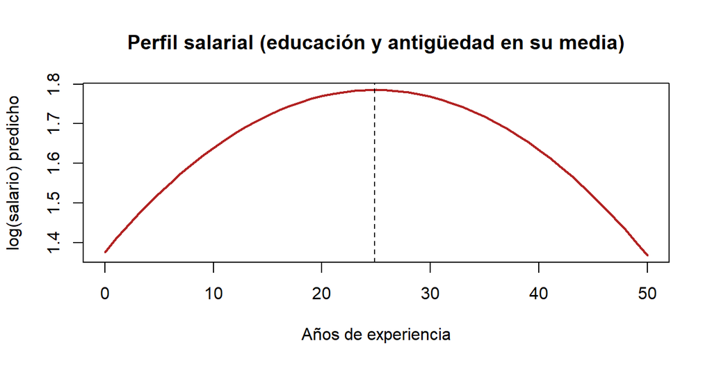

```r
grilla <- data.frame(exper = 0:50, educ = mean(wage1$educ), tenure = mean(wage1$tenure))
plot(grilla$exper, predict(m_cuad, grilla), type = "l", lwd = 2, col = "firebrick",
     xlab = "Años de experiencia", ylab = "log(salario) predicho",
     main = "Perfil salarial (educación y antigüedad en su media)")
abline(v = punto_giro, lty = 2)
```

Para saber si hace falta el cuadrado, alcanza con mirar si el coeficiente de `I(exper^2)` es significativo.

# 6 Significatividad

## 6.1 Test t: cada coeficiente por separado

$H_0: \beta_j = 0$ (la variable no tiene efecto parcial). Si el p-valor es menor que el nivel elegido (en general 5%), se rechaza $H_0$: la variable es **estadísticamente significativa**.

```r
coeftest(m_cuad)          # misma tabla que summary(), más compacta
```

```
#>
#> t test of coefficients:
#>
#>              Estimate Std. Error t value             Pr(>|t|)
#> (Intercept)  0.198345   0.101956    1.95                0.052 .
#> educ         0.085349   0.007188   11.87 < 0.0000000000000002 ***
#> exper        0.032854   0.005114    6.42       0.000000000298 ***
#> I(exper^2)  -0.000661   0.000111   -5.94       0.000000005078 ***
#> tenure       0.020841   0.003004    6.94       0.000000000012 ***
#> ---
#> Signif. codes:  0 '***' 0.001 '**' 0.01 '*' 0.05 '.' 0.1 ' ' 1
```

```r
confint(m_cuad, level = 0.95)
```

```
#>                  2.5 %     97.5 %
#> (Intercept) -0.0019501  0.3986392
#> educ         0.0712270  0.0994709
#> exper        0.0228085  0.0428999
#> I(exper^2)  -0.0008789 -0.0004423
#> tenure       0.0149404  0.0267422
```

Leer el intervalo de confianza es equivalente: si **no contiene al cero**, el coeficiente es significativo a ese nivel. Además da una idea del rango plausible del efecto, que es más informativo que un sí/no.

**Significativo no es lo mismo que importante.** Con muestras grandes, efectos minúsculos salen significativos. Siempre mirar también la **magnitud** del coeficiente y preguntarse si es económicamente relevante.

## 6.2 Test F global

Es el `F-statistic` al pie de `summary()`. $H_0$: ninguna regresora sirve (todos los $\beta_j = 0$, salvo el intercepto). Casi siempre se rechaza; si no se rechaza, el modelo no explica nada.

## 6.3 Test F de significatividad conjunta

Sirve para testear **varios coeficientes a la vez**. Casos típicos: todas las dummies de una categórica, un término y su cuadrado, un grupo de controles.

Hay dos formas equivalentes:

```r
# (a) Comparando el modelo con y sin esas variables
m_sin_region <- lm(wage ~ educ + exper + tenure, data = wage1)
anova(m_sin_region, m_region)
```

| Res.Df | RSS | Df | Sum of Sq | F | Pr(>F) |
| --- | --- | --- | --- | --- | --- |
| 522 | 4966 | NA | NA | NA | NA |
| 519 | 4881 | 3 | 85.55 | 3.032 | 0.0289 |

```r
# (b) Escribiendo las restricciones
linearHypothesis(m_region, c("regionCentro-norte = 0", "regionOeste = 0", "regionSur = 0"))
```

| Res.Df | RSS | Df | Sum of Sq | F | Pr(>F) |
| --- | --- | --- | --- | --- | --- |
| 522 | 4966 | NA | NA | NA | NA |
| 519 | 4881 | 3 | 85.55 | 3.032 | 0.0289 |

`linearHypothesis()` también permite testear otras restricciones, por ejemplo que dos coeficientes sean iguales:

```r
linearHypothesis(m_mult, "exper = tenure")
```

| Res.Df | RSS | Df | Sum of Sq | F | Pr(>F) |
| --- | --- | --- | --- | --- | --- |
| 523 | 5200 | NA | NA | NA | NA |
| 522 | 4966 | 1 | 233.9 | 24.58 | 0 |

Puede pasar que cada dummy por separado **no** sea significativa pero en conjunto **sí** (o al revés). Para decidir si una categórica se queda en el modelo, siempre usar el test conjunto.

# 7 Diagnóstico: problemas, tests y soluciones

## 7.1 Mapa de esta sección

| Problema | ¿Qué rompe? | Test en R | $H_0$ | Solución en R |
| --- | --- | --- | --- | --- |
| Forma funcional incorrecta | Sesgo | `resettest()` | Forma correcta | Logs, cuadrados, interacciones |
| Multicolinealidad | Nada (pero EE grandes) | `vif()` | — | Quitar/combinar variables, más datos |
| Heteroscedasticidad | EE, tests t y F | `bptest()` (BP y White) | Homoscedasticidad | Errores robustos de White: `vcovHC()` |
| No normalidad | Tests en muestras chicas | `shapiro.test()`, `jarque.bera.test()` | Normalidad | Muestra grande (TCL), logs, bootstrap |
| Autocorrelación (series) | EE, tests t y F | `dwtest()`, `bgtest()` | No autocorrelación | Errores de Newey-West: `NeweyWest()` |
| Endogeneidad | **Sesgo e inconsistencia** | Wu-Hausman | Exogeneidad | Variables instrumentales: `ivreg()` |

**La lógica de todos los tests es la misma**: la $H_0$ es “no hay problema”. **p-valor < 0,05 → se rechaza $H_0$ → hay evidencia del problema.** p-valor ≥ 0,05 → no hay evidencia suficiente del problema.

Una primera mirada visual rápida la dan los gráficos de diagnóstico de `lm`:

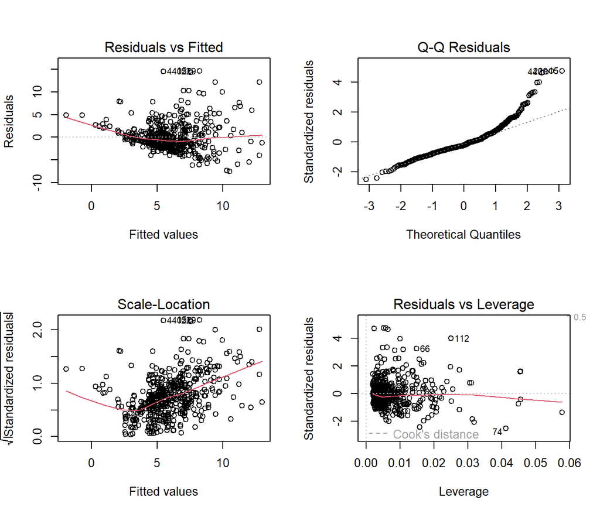

```r
par(mfrow = c(2, 2))
plot(m_mult)
```

```r
par(mfrow = c(1, 1))
```

| Gráfico | Qué mirar |
| --- | --- |
| Residuals vs Fitted | Nube sin forma alrededor de 0. Una curva sugiere mala forma funcional |
| Normal Q-Q | Puntos sobre la diagonal = residuos aproximadamente normales |
| Scale-Location | Línea plana = varianza constante. Si sube, heteroscedasticidad |
| Residuals vs Leverage | Puntos fuera de las líneas de Cook = observaciones muy influyentes |

## 7.2 Forma funcional: test RESET

Agrega potencias de los valores predichos ($\hat y^2, \hat y^3$) y testea si aportan algo. Si aportan, falta alguna no linealidad.

```r
resettest(m_mult, power = 2:3, type = "fitted")   # lineal en niveles
```

```
#>
#>  RESET test
#>
#> data:  m_mult
#> RESET = 12, df1 = 2, df2 = 520, p-value = 0.00001
```

```r
resettest(m_cuad, power = 2:3, type = "fitted")   # log + cuadrado
```

```
#>
#>  RESET test
#>
#> data:  m_cuad
#> RESET = 5.6, df1 = 2, df2 = 519, p-value = 0.004
```

El modelo en niveles rechaza con fuerza. El modelo con logaritmo y cuadrado mejora (el estadístico baja mucho) pero todavía rechaza al 1%: quizás falten interacciones o variables como `female`. Si el RESET rechaza, probar logaritmos, cuadrados o interacciones. El test **no dice qué** falta, solo que algo falta.

## 7.3 Multicolinealidad: VIF

No es un problema de sesgo: los estimadores siguen siendo insesgados, pero con regresoras muy correlacionadas entre sí los errores estándar se inflan.

```r
vif(m_mult)
```

```
#>   educ  exper tenure
#>  1.113  1.478  1.349
```

```r
vif(m_cuad)   # exper y exper^2 tienen VIF alto por construcción: no es un problema
```

```
#>       educ      exper I(exper^2)     tenure
#>      1.141     13.866     13.493      1.356
```

Regla práctica: VIF > 10 merece atención. **Qué hacer**: si las variables colineales son controles, en general nada. Si importa separar sus efectos: quitar una variable redundante, combinarlas en un índice o conseguir más datos. Nunca sacar una variable relevante solo para bajar el VIF (se genera sesgo por omisión).

## 7.4 Heteroscedasticidad

**Qué es**: la varianza del error cambia con las regresoras (por ejemplo, salarios más dispersos entre quienes tienen más educación). **Qué rompe**: los coeficientes siguen siendo insesgados, pero **los errores estándar están mal** y por eso los tests t y F y los intervalos no son confiables.

### 7.4.1 Detectar

Gráfico: residuos contra valores predichos. Un “embudo” es la señal típica.

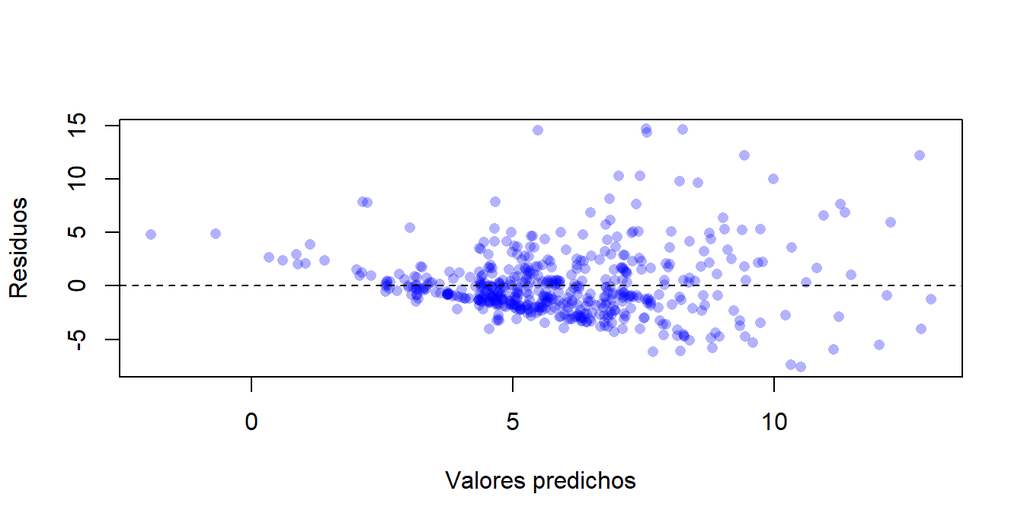

```r
plot(fitted(m_mult), residuals(m_mult), pch = 16, col = rgb(0, 0, 1, 0.3),
     xlab = "Valores predichos", ylab = "Residuos")
abline(h = 0, lty = 2)
```

**Test de Breusch-Pagan.** Regresa los residuos al cuadrado contra las regresoras. $H_0$: homoscedasticidad.

```r
bptest(m_mult)
```

```
#>
#>  studentized Breusch-Pagan test
#>
#> data:  m_mult
#> BP = 43, df = 3, p-value = 0.000000002
```

**Test de White.** Igual que BP pero agrega cuadrados e interacciones de las regresoras, así detecta formas no lineales de heteroscedasticidad. Con `bptest()` se especifica la regresión auxiliar a mano:

```r
# White completo: variables, cuadrados y productos cruzados
bptest(m_mult, ~ educ * exper * tenure + I(educ^2) + I(exper^2) + I(tenure^2),
       data = wage1)
```

```
#>
#>  studentized Breusch-Pagan test
#>
#> data:  m_mult
#> BP = 65, df = 10, p-value = 0.0000000004
```

```r
# Versión simplificada de White (útil con muchas regresoras): usa y sombrero y su cuadrado
bptest(m_mult, ~ fitted(m_mult) + I(fitted(m_mult)^2))
```

```
#>
#>  studentized Breusch-Pagan test
#>
#> data:  m_mult
#> BP = 52, df = 2, p-value = 0.000000000006
```

En ambos casos el p-valor es muy chico: **hay heteroscedasticidad**.

### 7.4.2 Solucionar: errores estándar robustos de White

Se mantienen los mismos coeficientes de MCO y se recalculan los errores estándar con una fórmula válida con o sin heteroscedasticidad. En R: `coeftest()` + `vcovHC()`. Usamos `type = "HC1"`, que es la corrección que usa Stata (`, robust`).

```r
coeftest(m_mult)                                         # EE clásicos
```

```
#>
#> t test of coefficients:
#>
#>             Estimate Std. Error t value             Pr(>|t|)
#> (Intercept)  -2.8727     0.7290   -3.94    0.000092247424963 ***
#> educ          0.5990     0.0513   11.68 < 0.0000000000000002 ***
#> exper         0.0223     0.0121    1.85                0.064 .
#> tenure        0.1693     0.0216    7.82    0.000000000000029 ***
#> ---
#> Signif. codes:  0 '***' 0.001 '**' 0.01 '*' 0.05 '.' 0.1 ' ' 1
```

```r
coeftest(m_mult, vcov = vcovHC(m_mult, type = "HC1"))    # EE robustos de White
```

```
#>
#> t test of coefficients:
#>
#>             Estimate Std. Error t value             Pr(>|t|)
#> (Intercept)  -2.8727     0.8074   -3.56              0.00041 ***
#> educ          0.5990     0.0610    9.82 < 0.0000000000000002 ***
#> exper         0.0223     0.0106    2.12              0.03477 *
#> tenure        0.1693     0.0293    5.78          0.000000013 ***
#> ---
#> Signif. codes:  0 '***' 0.001 '**' 0.01 '*' 0.05 '.' 0.1 ' ' 1
```

Los coeficientes son idénticos; cambian los errores estándar, los t y los p-valores. Con errores robustos también hay que hacer los tests conjuntos y los intervalos:

```r
coefci(m_mult, vcov. = vcovHC(m_mult, type = "HC1"))                   # IC robustos
```

```
#>                 2.5 %   97.5 %
#> (Intercept) -4.458918 -1.28655
#> educ         0.479102  0.71883
#> exper        0.001604  0.04307
#> tenure       0.111751  0.22679
```

```r
linearHypothesis(m_region, c("regionCentro-norte = 0", "regionOeste = 0", "regionSur = 0"),
                 vcov. = vcovHC(m_region, type = "HC1"))              # F robusto
```

| Res.Df | Df | F | Pr(>F) |
| --- | --- | --- | --- |
| 522 | NA | NA | NA |
| 519 | 3 | 2.739 | 0.0428 |

**En la práctica, con datos de corte transversal se reportan casi siempre errores robustos**, haya o no evidencia de heteroscedasticidad: si no la hay, dan casi lo mismo que los clásicos; si la hay, son los correctos.

A veces, pasar la variable dependiente a **logaritmo** también reduce mucho la heteroscedasticidad (compará `bptest(m_loglin)` con `bptest(m_mult)`), porque comprime los valores grandes.

## 7.5 Normalidad de los residuos

**Qué rompe**: nada de los coeficientes. La normalidad solo hace falta para que los tests t y F sean **exactos en muestras chicas**. Con muestras grandes (digamos, más de 100 o 200 observaciones) el Teorema Central del Límite garantiza que los tests funcionan aproximadamente bien igual.

### 7.5.1 Detectar

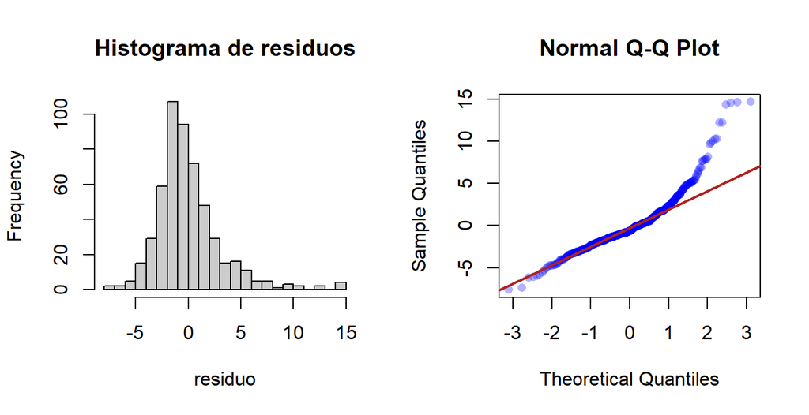

```r
res <- residuals(m_mult)
par(mfrow = c(1, 2))
hist(res, breaks = 30, main = "Histograma de residuos", col = "grey80", xlab = "residuo")
qqnorm(res, pch = 16, col = rgb(0, 0, 1, 0.3)); qqline(res, col = "firebrick", lwd = 2)
```

```r
par(mfrow = c(1, 1))
```

```r
shapiro.test(res)        # Shapiro-Wilk (hasta 5000 observaciones)
```

```
#>
#>  Shapiro-Wilk normality test
#>
#> data:  res
#> W = 0.89, p-value <0.0000000000000002
```

```r
jarque.bera.test(res)    # Jarque-Bera: mira asimetría y curtosis
```

```
#>
#>  Jarque Bera Test
#>
#> data:  res
#> X-squared = 651, df = 2, p-value <0.0000000000000002
```

$H_0$: los residuos son normales. Acá se rechaza con claridad: la cola derecha es larga (algunos salarios muy altos).

### 7.5.2 Solucionar

1. **Si la muestra es grande**, en general no hace falta hacer nada: los tests son válidos asintóticamente. Esta base tiene 526 observaciones.
2. **Transformar** la variable dependiente (logaritmo): suele simetrizar los residuos.

```r
jarque.bera.test(residuals(m_loglin))   # mejora mucho respecto del modelo en niveles
```

```
#>
#>  Jarque Bera Test
#>
#> data:  residuals(m_loglin)
#> X-squared = 21, df = 2, p-value = 0.00003
```

3. **Bootstrap** (lo que vimos en la clase de remuestreo): se re-estima el modelo en muchas muestras con reposición y se arma el intervalo con los percentiles. No necesita suponer normalidad.

```r
set.seed(123)
B <- 2000
b_educ <- numeric(B)
for (i in 1:B) {
  filas <- sample(nrow(wage1), replace = TRUE)
  b_educ[i] <- coef(lm(wage ~ educ + exper + tenure, data = wage1[filas, ]))["educ"]
}
quantile(b_educ, c(0.025, 0.975))   # IC bootstrap al 95%
```

```
#>   2.5%  97.5%
#> 0.4846 0.7206
```

```r
confint(m_mult)["educ", ]           # IC clásico, para comparar
```

```
#>  2.5 % 97.5 %
#> 0.4982 0.6997
```

Con muestras grandes, los tests de normalidad rechazan ante desvíos minúsculos. No usar un rechazo de Shapiro o Jarque-Bera como excusa para descartar un modelo: mirar el QQ-plot y el tamaño de muestra.

## 7.6 Autocorrelación

**Qué es**: los errores de distintos períodos están correlacionados (un shock de este año sigue afectando el año que viene). Es un problema de **series de tiempo**. En un corte transversal con orden arbitrario de las filas no tiene sentido testearla. **Qué rompe**: igual que la heteroscedasticidad, los coeficientes siguen siendo insesgados (si las regresoras son exógenas) pero los errores estándar están mal, casi siempre subestimados.

Ejemplo: curva de Phillips estática con datos anuales de EE.UU.

```r
data("phillips")
phillips <- phillips %>% filter(year <= 1996)
m_phil <- lm(inf ~ unem, data = phillips)
coeftest(m_phil)
```

```
#>
#> t test of coefficients:
#>
#>             Estimate Std. Error t value Pr(>|t|)
#> (Intercept)    1.424      1.719    0.83     0.41
#> unem           0.468      0.289    1.62     0.11
```

### 7.6.1 Detectar

Gráfico de residuos en el tiempo: rachas largas de residuos del mismo signo indican autocorrelación positiva.

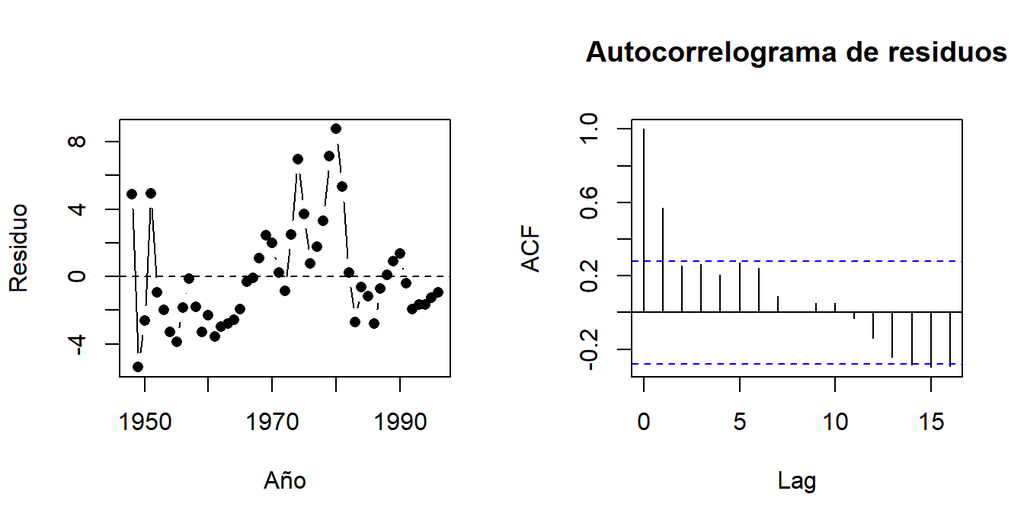

```r
par(mfrow = c(1, 2))
plot(phillips$year, residuals(m_phil), type = "b", pch = 16,
     xlab = "Año", ylab = "Residuo"); abline(h = 0, lty = 2)
acf(residuals(m_phil), main = "Autocorrelograma de residuos")
```

```r
par(mfrow = c(1, 1))
```

**Durbin-Watson**: detecta autocorrelación de orden 1. El estadístico va de 0 a 4; cerca de 2 = sin autocorrelación, cerca de 0 = autocorrelación positiva.

```r
dwtest(m_phil)
```

```
#>
#>  Durbin-Watson test
#>
#> data:  m_phil
#> DW = 0.8, p-value = 0.0000008
#> alternative hypothesis: true autocorrelation is greater than 0
```

**Breusch-Godfrey**: más general (permite varios rezagos y modelos con la $y$ rezagada como regresora, donde Durbin-Watson no sirve).

```r
bgtest(m_phil, order = 1)
```

```
#>
#>  Breusch-Godfrey test for serial correlation of order up to 1
#>
#> data:  m_phil
#> LM test = 18, df = 1, p-value = 0.00002
```

```r
bgtest(m_phil, order = 2)
```

```
#>
#>  Breusch-Godfrey test for serial correlation of order up to 2
#>
#> data:  m_phil
#> LM test = 18, df = 2, p-value = 0.0001
```

En ambos casos se rechaza $H_0$: **hay autocorrelación**.

### 7.6.2 Solucionar

**(a) Errores estándar de Newey-West (HAC).** Es el equivalente de White para series de tiempo: robustos a heteroscedasticidad **y** autocorrelación. Mismos coeficientes, distintos errores estándar.

```r
coeftest(m_phil, vcov = NeweyWest(m_phil, lag = 2, prewhite = FALSE))
```

```
#>
#> t test of coefficients:
#>
#>             Estimate Std. Error t value Pr(>|t|)
#> (Intercept)    1.424      1.460    0.97     0.33
#> unem           0.468      0.280    1.67     0.10
```

**(b) Revisar la especificación.** Muchas veces la autocorrelación es señal de un modelo mal planteado (dinámica omitida). Opciones: agregar la variable dependiente rezagada o trabajar en diferencias. Por ejemplo, la curva de Phillips aumentada por expectativas usa el **cambio** en la inflación:

```r
m_phil_dif <- lm(cinf ~ unem, data = phillips)   # cinf = inf - inf del año anterior
coeftest(m_phil_dif)
```

```
#>
#> t test of coefficients:
#>
#>             Estimate Std. Error t value Pr(>|t|)
#> (Intercept)    3.031      1.377    2.20    0.033 *
#> unem          -0.543      0.230   -2.36    0.023 *
#> ---
#> Signif. codes:  0 '***' 0.001 '**' 0.01 '*' 0.05 '.' 0.1 ' ' 1
```

```r
bgtest(m_phil_dif, order = 1)
```

```
#>
#>  Breusch-Godfrey test for serial correlation of order up to 1
#>
#> data:  m_phil_dif
#> LM test = 0.062, df = 1, p-value = 0.8
```

En diferencias, el Breusch-Godfrey ya no rechaza y aparece el *trade-off* esperado: más desempleo se asocia a una caída de la inflación.

Existen también estimadores que corrigen la autocorrelación modelándola (Cochrane-Orcutt, Prais-Winsten; paquetes `orcutt` y `prais`). En un curso aplicado, **Newey-West + revisar la especificación** cubre la gran mayoría de los casos.

# 8 Endogeneidad y variables instrumentales

## 8.1 El problema

Una regresora es **endógena** cuando está correlacionada con el error. Entonces MCO es **sesgado e inconsistente**: a diferencia de los problemas anteriores, no alcanza con corregir los errores estándar porque **el coeficiente mismo está mal**. Y no mejora con más datos.

Fuentes típicas:

| Fuente | Ejemplo |
| --- | --- |
| Variable omitida | Habilidad: afecta al salario y a la educación, y no la observamos |
| Simultaneidad | Precio y cantidad se determinan a la vez; policía y crimen |
| Error de medición en $x$ | Ingreso autodeclarado |

No hay un test que detecte la endogeneidad solo con MCO: el primer diagnóstico es **pensar el problema** (¿qué hay en el error que pueda estar correlacionado con mi $x$?). La primera línea de defensa es agregar controles; cuando la variable omitida no se puede medir, se recurre a instrumentos.

## 8.2 La solución: variables instrumentales (MC2E)

Un instrumento $z$ es una variable que:

1. **Relevancia**: está correlacionada con la regresora endógena $x$. *Se puede testear.*
2. **Exogeneidad**: no está correlacionada con el error, es decir, afecta a $y$ **solo a través de** $x$. *No se puede testear con un solo instrumento: se argumenta.*

Mínimos cuadrados en dos etapas (MC2E) hace, conceptualmente: (1) regresar $x$ contra $z$ y los controles, y quedarse con $\hat x$; (2) regresar $y$ contra $\hat x$ y los controles. Pero **no hay que hacerlo a mano en dos `lm()`**: los errores estándar de la segunda etapa salen mal. Se usa `ivreg()`.

## 8.3 Ejemplo: retorno a la educación de mujeres casadas

La educación es probablemente endógena (habilidad omitida). Usamos como instrumentos la educación del padre y de la madre.

```r
data("mroz")
mroz_trab <- mroz %>% filter(inlf == 1)   # solo las que trabajan (tienen salario)

m_ols <- lm(lwage ~ educ + exper + I(exper^2), data = mroz_trab)
```

**Primera etapa**: ¿los instrumentos son relevantes?

```r
primera <- lm(educ ~ fatheduc + motheduc + exper + I(exper^2), data = mroz_trab)
coeftest(primera)
```

```
#>
#> t test of coefficients:
#>
#>             Estimate Std. Error t value             Pr(>|t|)
#> (Intercept)  9.10264    0.42656   21.34 < 0.0000000000000002 ***
#> fatheduc     0.18955    0.03376    5.62          0.000000036 ***
#> motheduc     0.15760    0.03589    4.39          0.000014298 ***
#> exper        0.04523    0.04025    1.12                 0.26
#> I(exper^2)  -0.00101    0.00120   -0.84                 0.40
#> ---
#> Signif. codes:  0 '***' 0.001 '**' 0.01 '*' 0.05 '.' 0.1 ' ' 1
```

```r
linearHypothesis(primera, c("fatheduc = 0", "motheduc = 0"))
```

| Res.Df | RSS | Df | Sum of Sq | F | Pr(>F) |
| --- | --- | --- | --- | --- | --- |
| 425 | 2219 | NA | NA | NA | NA |
| 423 | 1759 | 2 | 460.6 | 55.4 | 0 |

Regla práctica: **F de la primera etapa > 10** → instrumentos fuertes. Si es menor, son **instrumentos débiles** y MC2E puede estar tan sesgado como MCO.

**Estimación por MC2E**. En `ivreg()` la fórmula tiene dos partes separadas por `|`: a la izquierda el modelo, a la derecha **todas las variables exógenas** (instrumentos + controles exógenos; los controles se repiten).

```r
m_iv <- ivreg(lwage ~ educ + exper + I(exper^2) |
                fatheduc + motheduc + exper + I(exper^2),
              data = mroz_trab)
summary(m_iv, diagnostics = TRUE)
```

```
#>
#> Call:
#> ivreg(formula = lwage ~ educ + exper + I(exper^2) | fatheduc +
#>     motheduc + exper + I(exper^2), data = mroz_trab)
#>
#> Residuals:
#>     Min      1Q  Median      3Q     Max
#> -3.0986 -0.3196  0.0551  0.3689  2.3493
#>
#> Coefficients:
#>              Estimate Std. Error t value Pr(>|t|)
#> (Intercept)  0.048100   0.400328    0.12   0.9044
#> educ         0.061397   0.031437    1.95   0.0515 .
#> exper        0.044170   0.013432    3.29   0.0011 **
#> I(exper^2)  -0.000899   0.000402   -2.24   0.0257 *
#>
#> Diagnostic tests:
#>                  df1 df2 statistic             p-value
#> Weak instruments   2 423     55.40 <0.0000000000000002 ***
#> Wu-Hausman         1 423      2.79               0.095 .
#> Sargan             1  NA      0.38               0.539
#> ---
#> Signif. codes:  0 '***' 0.001 '**' 0.01 '*' 0.05 '.' 0.1 ' ' 1
#>
#> Residual standard error: 0.675 on 424 degrees of freedom
#> Multiple R-Squared: 0.136,   Adjusted R-squared: 0.13
#> Wald test: 8.14 on 3 and 424 DF,  p-value: 0.0000279
```

```r
cbind(MCO = coef(m_ols), MC2E = coef(m_iv))[1:2, ]
```

```
#>                 MCO   MC2E
#> (Intercept) -0.5220 0.0481
#> educ         0.1075 0.0614
```

Por MCO el retorno a la educación es 10.7% por año; por MC2E, 6.1%. Es consistente con que MCO **sobreestima** el efecto porque la educación “absorbe” parte de la habilidad. Notar que el error estándar de MC2E es mayor: es el precio de usar instrumentos.

## 8.4 Los diagnósticos de `ivreg()`

| Test | $H_0$ | Si se rechaza (p < 0,05) |
| --- | --- | --- |
| **Weak instruments** | Instrumentos débiles | Bien: los instrumentos son relevantes (mirar además F > 10) |
| **Wu-Hausman** | La variable es exógena (MCO y MC2E no difieren) | Hay endogeneidad: preferir MC2E. Si no se rechaza, MCO es válido y más preciso |
| **Sargan** | Todos los instrumentos son exógenos | Al menos un instrumento es inválido. Solo existe con más instrumentos que variables endógenas |

En este ejemplo: los instrumentos son fuertes, Sargan no rechaza (no hay evidencia contra su validez) y Wu-Hausman rechaza solo al 10% (evidencia débil de endogeneidad).

Con heteroscedasticidad, los errores robustos también se piden en `ivreg()`:

```r
coeftest(m_iv, vcov = vcovHC(m_iv, type = "HC1"))
```

```
#>
#> t test of coefficients:
#>
#>              Estimate Std. Error t value Pr(>|t|)
#> (Intercept)  0.048100   0.429798    0.11   0.9109
#> educ         0.061397   0.033339    1.84   0.0662 .
#> exper        0.044170   0.015546    2.84   0.0047 **
#> I(exper^2)  -0.000899   0.000430   -2.09   0.0372 *
#> ---
#> Signif. codes:  0 '***' 0.001 '**' 0.01 '*' 0.05 '.' 0.1 ' ' 1
```

**El mayor riesgo con VI es un mal instrumento**, no un mal código. Antes de estimar, escribir en una oración por qué $z$ afecta a $y$ **solo** a través de $x$. Acá, por ejemplo, podría objetarse que padres más educados transmiten también habilidad o contactos, lo que violaría la exogeneidad.

# 9 Datos de panel: efectos fijos, aleatorios y test de Hausman

## 9.1 Por qué panel

Con datos de panel observamos **las mismas unidades en varios períodos**. Eso permite controlar por características **inobservables que no cambian en el tiempo** (habilidad, cultura de una empresa, geografía de una provincia), que son una fuente típica de endogeneidad:

$$y_{it} = \beta_0 + \beta_1 x_{it} + a_i
+ u_{it}$$

$a_i$ es el **efecto individual** inobservable. Hay tres formas de tratarlo:

| Modelo | Supuesto sobre $a_i$ | En `plm()` |
| --- | --- | --- |
| MCO agrupado (*pooled*) | No existe o no está correlacionado con nada | `model = "pooling"` |
| **Efectos fijos** (FE) | Puede estar correlacionado con las $x$: lo **elimina** | `model = "within"` |
| **Efectos aleatorios** (RE) | **No** está correlacionado con las $x$ | `model = "random"` |

## 9.2 Preparar los datos

`plm` necesita saber cuál es la unidad y cuál el tiempo (`index`).

```r
data("wagepan")
panel <- pdata.frame(wagepan, index = c("nr", "year"))
pdim(panel)   # 545 individuos, 8 años, panel balanceado
```

```
#> Balanced Panel: n = 545, T = 8, N = 4360
```

## 9.3 Estimar los tres modelos

```r
f_completa <- lwage ~ educ + black + hisp + exper + I(exper^2) + married + union + factor(year)
f_varian   <- lwage ~ I(exper^2) + married + union + factor(year)

m_pool <- plm(f_completa, data = panel, model = "pooling")
m_re   <- plm(f_completa, data = panel, model = "random")
m_fe   <- plm(f_varian,   data = panel, model = "within")

coeftest(m_fe)
```

```
#>
#> t test of coefficients:
#>
#>                   Estimate Std. Error t value             Pr(>|t|)
#> I(exper^2)       -0.005185   0.000704   -7.36     0.00000000000022 ***
#> married           0.046680   0.018310    2.55                0.011 *
#> union             0.080002   0.019310    4.14     0.00003503024006 ***
#> factor(year)1981  0.151191   0.021949    6.89     0.00000000000658 ***
#> factor(year)1982  0.252971   0.024418   10.36 < 0.0000000000000002 ***
#> factor(year)1983  0.354444   0.029242   12.12 < 0.0000000000000002 ***
#> factor(year)1984  0.490115   0.036227   13.53 < 0.0000000000000002 ***
#> factor(year)1985  0.617482   0.045244   13.65 < 0.0000000000000002 ***
#> factor(year)1986  0.765497   0.056128   13.64 < 0.0000000000000002 ***
#> factor(year)1987  0.925025   0.068773   13.45 < 0.0000000000000002 ***
#> ---
#> Signif. codes:  0 '***' 0.001 '**' 0.01 '*' 0.05 '.' 0.1 ' ' 1
```

**Efectos fijos no puede estimar variables que no cambian en el tiempo** (educación, raza, sexo, región de nacimiento): quedan absorbidas por $a_i$. Por eso `f_varian` no las incluye. Tampoco `exper` en niveles: con dummies de año, sube 1 por año para todos y queda colineal. Si el interés está en una variable fija en el tiempo, FE no sirve y hay que ir a RE (si el supuesto se sostiene).

**Interpretación de FE**: compara a cada individuo **consigo mismo** en distintos años. El coeficiente de `union` dice que, para una misma persona, pasar a estar sindicalizado se asocia a un salario 8% mayor.

```r
vars <- c("I(exper^2)", "married", "union")
cbind(Pooled = coef(m_pool)[vars], RE = coef(m_re)[vars], FE = coef(m_fe)[vars])
```

```
#>               Pooled        RE        FE
#> I(exper^2) -0.002412 -0.004724 -0.005185
#> married     0.108253  0.063986  0.046680
#> union       0.182461  0.106134  0.080002
```

El premio por estar casado cae mucho en FE respecto de pooled: buena parte de esa asociación se debía a características fijas de quienes se casan, no al matrimonio.

## 9.4 Elegir entre modelos

**¿Pooled o efectos fijos?** Test F de efectos individuales. $H_0$: no hay efectos individuales (pooled alcanza).

```r
m_pool_v <- plm(f_varian, data = panel, model = "pooling")
pFtest(m_fe, m_pool_v)
```

```
#>
#>  F test for individual effects
#>
#> data:  f_varian
#> F = 9.2, df1 = 544, df2 = 3805, p-value <0.0000000000000002
#> alternative hypothesis: significant effects
```

**¿Pooled o efectos aleatorios?** Test LM de Breusch-Pagan. $H_0$: la varianza de $a_i$ es cero (pooled alcanza).

```r
plmtest(m_pool, type = "bp")
```

```
#>
#>  Lagrange Multiplier Test - (Breusch-Pagan)
#>
#> data:  f_completa
#> chisq = 3204, df = 1, p-value <0.0000000000000002
#> alternative hypothesis: significant effects
```

**¿Efectos fijos o aleatorios? Test de Hausman.** Compara los coeficientes de FE y RE sobre **las mismas variables**. Si $a_i$ no está correlacionado con las $x$, ambos son consistentes y deberían dar parecido (RE es más eficiente). Si difieren sistemáticamente, RE es inconsistente.

$H_0$: $a_i$ no está correlacionado con las regresoras → **efectos aleatorios**. Si se rechaza → **efectos fijos**.

```r
m_re_v <- plm(f_varian, data = panel, model = "random")
phtest(m_fe, m_re_v)
```

```
#>
#>  Hausman Test
#>
#> data:  f_varian
#> chisq = 37, df = 10, p-value = 0.00006
#> alternative hypothesis: one model is inconsistent
```

Se rechaza $H_0$: **usar efectos fijos**.

**Árbol de decisión**

1. `pFtest()` y `plmtest()`: ¿hay efectos individuales? Si no, pooled.
2. `phtest()`: si hay efectos, ¿FE o RE? p < 0,05 → FE; p ≥ 0,05 → RE.
3. Siempre reportar errores **agrupados por individuo** (ver abajo).

## 9.5 Errores estándar en panel: agrupados (*clustered*)

En panel, los errores de un mismo individuo suelen estar correlacionados entre años (autocorrelación) y tener distinta varianza entre individuos (heteroscedasticidad). La corrección estándar es agrupar por individuo, que en `plm` se pide con `method = "arellano"`:

```r
coeftest(m_fe, vcov = vcovHC(m_fe, method = "arellano", type = "HC1", cluster = "group"))
```

```
#>
#> t test of coefficients:
#>
#>                   Estimate Std. Error t value             Pr(>|t|)
#> I(exper^2)       -0.005185   0.000809   -6.41        0.00000000017 ***
#> married           0.046680   0.020985    2.22              0.02617 *
#> union             0.080002   0.022722    3.52              0.00044 ***
#> factor(year)1981  0.151191   0.025541    5.92        0.00000000352 ***
#> factor(year)1982  0.252971   0.028636    8.83 < 0.0000000000000002 ***
#> factor(year)1983  0.354444   0.034829   10.18 < 0.0000000000000002 ***
#> factor(year)1984  0.490115   0.045416   10.79 < 0.0000000000000002 ***
#> factor(year)1985  0.617482   0.056757   10.88 < 0.0000000000000002 ***
#> factor(year)1986  0.765497   0.071179   10.75 < 0.0000000000000002 ***
#> factor(year)1987  0.925025   0.083979   11.01 < 0.0000000000000002 ***
#> ---
#> Signif. codes:  0 '***' 0.001 '**' 0.01 '*' 0.05 '.' 0.1 ' ' 1
```

Es la versión panel de los errores robustos de White: mismos coeficientes, errores estándar válidos.

# 10 Extra: cuando la variable dependiente es binaria

Si $y$ vale 0 o 1 (trabaja / no trabaja, compra / no compra, default / no default), `lm()` estima un **modelo lineal de probabilidad** (MPL): los coeficientes son cambios en la **probabilidad**. Es fácil de interpretar, pero puede predecir probabilidades fuera de [0,1] y es heteroscedástico por construcción (usar siempre errores robustos). Las alternativas son logit y probit, con `glm()`.

```r
f_part <- inlf ~ nwifeinc + educ + exper + I(exper^2) + age + kidslt6 + kidsge6

m_mpl    <- lm(f_part, data = mroz)
m_logit  <- glm(f_part, data = mroz, family = binomial(link = "logit"))
m_probit <- glm(f_part, data = mroz, family = binomial(link = "probit"))

coeftest(m_mpl, vcov = vcovHC(m_mpl, type = "HC1"))
```

```
#>
#> t test of coefficients:
#>
#>              Estimate Std. Error t value            Pr(>|t|)
#> (Intercept)  0.585519   0.152260    3.85             0.00013 ***
#> nwifeinc    -0.003405   0.001525   -2.23             0.02585 *
#> educ         0.037995   0.007266    5.23 0.00000022143384054 ***
#> exper        0.039492   0.005810    6.80 0.00000000002185379 ***
#> I(exper^2)  -0.000596   0.000190   -3.14             0.00177 **
#> age         -0.016091   0.002399   -6.71 0.00000000003922190 ***
#> kidslt6     -0.261810   0.031783   -8.24 0.00000000000000079 ***
#> kidsge6      0.013012   0.013533    0.96             0.33660
#> ---
#> Signif. codes:  0 '***' 0.001 '**' 0.01 '*' 0.05 '.' 0.1 ' ' 1
```

**Los coeficientes de logit y probit no se interpretan directamente** como cambios en la probabilidad. Solo su signo y significatividad son directamente legibles. Para magnitudes se calculan **efectos marginales promedio** (AME):

```r
summary(margins(m_logit))
```

| factor | AME | SE | z | p | lower | upper |
| --- | --- | --- | --- | --- | --- | --- |
| age | -0.0157 | 0.0024 | -6.6027 | 0.0000 | -0.0204 | -0.0111 |
| educ | 0.0395 | 0.0073 | 5.4145 | 0.0000 | 0.0252 | 0.0538 |
| exper | 0.0254 | 0.0022 | 11.3686 | 0.0000 | 0.0210 | 0.0298 |
| kidsge6 | 0.0107 | 0.0133 | 0.8051 | 0.4207 | -0.0154 | 0.0369 |
| kidslt6 | -0.2578 | 0.0319 | -8.0696 | 0.0000 | -0.3204 | -0.1951 |
| nwifeinc | -0.0038 | 0.0015 | -2.5714 | 0.0101 | -0.0067 | -0.0009 |

Por ejemplo, tener un hijo menor de 6 años más reduce la probabilidad de participar en el mercado laboral en unos 26 puntos porcentuales, en promedio. Los AME de logit, probit y el coeficiente del MPL suelen ser parecidos.

# 11 Presentar resultados

Para un informe, en lugar de pegar salidas de `summary()`, conviene una tabla con los modelos lado a lado. `modelsummary()` lo hace y permite pedir errores robustos:

```r
modelsummary(
  list("Niveles" = m_mult, "Log-lin" = m_loglin, "Log + cuadrado" = m_cuad),
  vcov      = "HC1",                       # errores robustos de White
  stars     = TRUE,
  gof_map   = c("nobs", "r.squared", "adj.r.squared"),
  coef_rename = c("I(exper^2)" = "exper²"),
  notes     = "Errores estándar robustos (HC1) entre paréntesis."
)
```

|  | Niveles | Log-lin | Log + cuadrado |
| --- | --- | --- | --- |
| (Intercept) | -2.873*** | 0.284* | 0.198+ |
|  | (0.807) | (0.112) | (0.105) |
| educ | 0.599*** | 0.092*** | 0.085*** |
|  | (0.061) | (0.008) | (0.008) |
| exper | 0.022* | 0.004* | 0.033*** |
|  | (0.011) | (0.002) | (0.005) |
| tenure | 0.169*** | 0.022*** | 0.021*** |
|  | (0.029) | (0.004) | (0.004) |
| exper² |  |  | -0.001*** |
|  |  |  | (0.000) |
| Num.Obs. | 526 | 526 | 526 |
| R2 | 0.306 | 0.316 | 0.359 |
| R2 Adj. | 0.302 | 0.312 | 0.355 |

+ p < 0.1, * p < 0.05, ** p < 0.01, *** p < 0.001  
Errores estándar robustos (HC1) entre paréntesis.

Con `output = "tabla.docx"` o `output = "tabla.png"` se exporta directamente.

# 12 Receta final

1. **Mirar los datos**: `summary()`, histogramas, dispersión. ¿Asimetría? → log.
2. **Plantear el modelo** pensando en qué variables omitidas podrían sesgarlo.
3. **Estimar** con `lm()` e **interpretar** signo y magnitud (ceteris paribus; cuidado con logs, cuadrados e interacciones).
4. **Forma funcional**: `resettest()`. Si rechaza, probar logs, cuadrados, interacciones.
5. **Heteroscedasticidad**: `bptest()` (BP y White). En corte transversal, reportar **errores robustos** `vcovHC(..., type = "HC1")` igual.
6. **Autocorrelación** (solo series de tiempo): `dwtest()`, `bgtest()`. Corregir con `NeweyWest()` y revisar la dinámica.
7. **Normalidad**: QQ-plot, `jarque.bera.test()`. Con muestra grande, no preocuparse. Con muestra chica, log o bootstrap.
8. **Significatividad**: t individuales, F conjunta para grupos de variables (`linearHypothesis()`), **con la matriz de varianzas robusta**.
9. **¿Endogeneidad?** Si hay una razón fuerte y un buen instrumento: `ivreg()` con `diagnostics = TRUE` (F > 10, Wu-Hausman, Sargan).
10. **¿Panel?** `plm()`: FE vs RE con `phtest()`, errores agrupados por individuo.
11. **Reportar** con `modelsummary()` y describir en palabras qué significa cada coeficiente relevante.

## 12.1 Tabla de funciones

| Tarea | Función | Paquete |
| --- | --- | --- |
| Estimar MCO | `lm(y ~ x1 + x2, data)` | base |
| Dummies desde categórica | `factor()`, `relevel(ref = )` | base |
| Interacción | `x1 * x2` o `x1:x2` | base |
| Cuadrado / log | `I(x^2)`, `log(x)` | base |
| Coeficientes con EE robustos | `coeftest(m, vcov = vcovHC(m, type = "HC1"))` | lmtest, sandwich |
| IC | `confint()`, `coefci(m, vcov. = )` | base, lmtest |
| F conjunta | `linearHypothesis()`, `anova(m_r, m_nr)` | car, base |
| RESET | `resettest()` | lmtest |
| VIF | `vif()` | car |
| Breusch-Pagan / White | `bptest()` | lmtest |
| Normalidad | `shapiro.test()`, `jarque.bera.test()` | base, tseries |
| Autocorrelación | `dwtest()`, `bgtest()` | lmtest |
| EE Newey-West | `coeftest(m, vcov = NeweyWest(m))` | sandwich |
| Variables instrumentales | `ivreg(y ~ x + w \| z + w)` | AER |
| Panel | `plm(..., model = "within"/"random"/"pooling")` | plm |
| Hausman | `phtest(m_fe, m_re)` | plm |
| Logit / probit | `glm(..., family = binomial("logit"/"probit"))` | base |
| Efectos marginales | `margins()` | margins |
| Tabla de resultados | `modelsummary()` | modelsummary |